[figure not shown]

# 1. Introdução

Temperatura, chuva e umidade, somadas às condições ambientais e sociais do território, modulam o risco de doenças transmissíveis, de agravos relacionados ao calor e a demanda por serviços de saúde (WHO, 2023; WMO; WHO, 2015).

Este boletim integra informações climáticas, territoriais e de saúde de Belém para acompanhar a variabilidade meteorológica, identificar eventos potencialmente danosos, descrever sua relação temporal e espacial com óbitos e internações e apontar áreas que demandam maior atenção, subsidiando a vigilância e a preparação do município.

# 2. Dados e metodologia

## 2.1 Dados do território, climáticos e meteorológicos

A caracterização territorial usa a malha dos oito Distritos Administrativos de Belém (CODEM; Lei Municipal nº 7.682/1994), as 14 bacias hidrográficas urbanas e as áreas de preservação e parques da base do CISC. A população vem do Censo Demográfico 2022 (IBGE), agregada de bairros para distritos. Os indicadores de renda, trabalho e saneamento vêm do Índice de Vulnerabilidade Social (IVS/IPEA) por Unidade de Desenvolvimento Humano (UDH), com base no Censo 2010, atribuídos ao distrito e ponderados pela população. Os mapas usam o sistema geodésico SIRGAS 2000 e mapa de fundo do OpenStreetMap.

As séries de precipitação pluviométrica, temperatura do ar e umidade relativa do ar são do Instituto Nacional de Meteorologia (INMET), estações convencional 82191 e automática A201. A fonte é escolhida por variável e por mês, sem interpolação de lacunas nem homogeneização entre os dois métodos de medição, o que deve ser considerado na leitura das tendências. A caracterização histórica cobre 1990 a 2025, com a normal climatológica 1991 a 2020 como referência (INMET, 2022); 2026 entra apenas nas análises do ano corrente. Um mês é válido para temperatura do ar e umidade relativa do ar com pelo menos 80% dos dias e no máximo cinco dias consecutivos ausentes; para precipitação pluviométrica, exige-se cobertura completa. Cada normal mensal exige pelo menos 24 anos válidos.

O índice de calor (IC) é calculado pela equação de Rothfusz (NOAA) com temperatura do ar e umidade relativa do ar simultâneas da A201, hora a hora, dentro do domínio de validade da equação (temperatura de pelo menos 26,7 °C e umidade relativa de pelo menos 40%), e resumido pelo máximo diário quando há ao menos 18 horas válidas, de 2015 em diante. O calendário médio por mês e dia é descritivo e não constitui normal climatológica.

## 2.2 Dados de saúde

Os dados de mortalidade (óbitos não fetais por causa básica) e de morbidade hospitalar (AIH do tipo normal, sem duplicidades e datadas pela internação) referem-se a residentes de Belém (2015 a 2026), obtidos, respectivamente, do Sistema de Informações sobre Mortalidade (SIM) e do Sistema de Informações Hospitalares (SIH/SUS), disponibilizados pelo DataSUS. Para mitigar o atraso de notificação, truncou-se o SIM na semana epidemiológica 33 de 2026 e o SIH em maio de 2026; os registros de 2025 e 2026 são preliminares e sujeitos a revisão. As bases são analisadas de forma independente, tratando períodos sem cobertura como dados ausentes, e não como zero.

Para evitar distorções na linha de base decorrentes da pandemia, excluíram-se das séries observadas e de referência os registros de COVID-19 (CID-10 U07.1, U07.2, U09.9, U10.9 e, desde 2020, B34.2; no SIH, também o procedimento 03.03.01.022-3). No SIM, excluíram-se ainda os códigos usados como substitutos da COVID-19 na primeira onda (J98.8 e J12.9) e, em abril e maio de 2020, os óbitos cardiovasculares (I00 a I99) e por diabetes (E10 a E14) associados a choque (R57) ou insuficiência aguda; mantiveram-se as pneumonias e as doenças respiratórias crônicas (J18 e J44). Essa escolha metodológica reduz a influência da pandemia sobre o perfil esperado, sem estimar o impacto pandêmico direto ou indireto.

A demanda cardiovascular por distrito baseia-se nas solicitações reguladas via SISREG (CID-10 I00 a I99), georreferenciadas por setor censitário. Trata-se de demanda por regulação, e não de internações efetivadas, expressa como taxa bruta acumulada no período, sem padronização etária. Em observância ao sigilo ético e à Lei Geral de Proteção de Dados (LGPD), os dados são apresentados exclusivamente de forma agregada.

## 2.3 Método

**Clima:** A série mensal é descrita por anomalias em relação à normal 1991 a 2020, tendência por década e decomposição em tendência, sazonalidade e resíduo, com ACF dos resíduos (Morettin; Toloi, 2006). Os quantis \(p\) = 0,05 a 0,95 da temperatura máxima diária são estimados por regressão quantílica (Koenker; Bassett, 1978), com \(d_t\) o dia do ano:

\[ Q_{p}(T_t) = \beta_{0}(p) + \beta_{1}(p)\,t + \sum_{k=1}^{2}\left[\gamma_{k}(p)\cos\!\left(\tfrac{2\pi k d_t}{365{,}25}\right) + \delta_{k}(p)\sin\!\left(\tfrac{2\pi k d_t}{365{,}25}\right)\right] \]

Episódio de calor é a sequência de pelo menos três dias acima do P90 sazonal fixo da temperatura máxima (normal 1991 a 2020, janela de ±15 dias). Pelo mesmo critério, noite quente é aquela em que a mínima noturna (18 h às 6 h, estação A201) supera o P90 ou o P95 sazonal, contando-se episódios de três ou mais noites; precipitação extrema é o dia com chuva acima do P95 sazonal dos dias chuvosos (pelo menos 1 mm).

**Saúde:** Em semanas epidemiológicas completas, o esperado é estimado por GAM binomial negativo (Bhaskaran et al., 2013; Wood, 2017), com spline cíclica da semana \(f_1\), tendência \(f_2\) e offset populacional quando disponível:

\[ Y_t \sim \mathrm{BN}(\mu_t, \theta), \qquad \log \mu_t = \beta_0 + f_1(\mathrm{SE}_t) + f_2(t) \; [+ \log N_t] \]

Cada ano é predito por um modelo ajustado sem ele, e o IP95% semanal é obtido por simulação. Na leptospirose, o limite superior é o quantil de 97,5% do mesmo modelo (Poisson, se não estimável). Os gatilhos comparam a razão observado/esperado entre semanas sem episódio, com episódio e até sete dias após.

**Vulnerabilidade territorial:** O IVT de cada distrito combina as dimensões social (IVS Renda e Trabalho), ambiental (domicílios sem água e esgoto adequados) e climática (temperatura dos sensores), padronizadas por mín-máx; o modelo principal usa \(w_s = w_a = w_c = 1/3\) e os cenários de sensibilidade, 60/20/20, 20/60/20, 20/20/60 e 45/45/10:

\[ X_{\text{norm}} = \frac{X - \min(X)}{\max(X) - \min(X)}, \qquad \mathrm{IVT} = w_s\,V_{\text{social}} + w_a\,V_{\text{ambiental}} + w_c\,V_{\text{clima}}, \quad \textstyle\sum w = 1 \]

# 3. Resultados

Os resultados são apresentados na mesma sequência das seis seções da matriz de análises do boletim.

## 3.1 Seção 1: Território e contextualização

**Área territorial:** Belém tem 1.059,458 km² (IBGE, Cidades e Estados), dos quais cerca de 65% correspondem à porção insular, com 42 ilhas; o restante é continental.

**Bioma e vegetação:** O município está no bioma Amazônia, em ambiente estuarino, com florestas de várzea e igapó, manguezais e remanescentes de terra firme; destacam-se o Parque Estadual do Utinga e o Bosque Rodrigues Alves.

**Hidrografia:** Belém é banhada a oeste pela Baía do Guajará e ao sul pelo Rio Guamá. A ocupação urbana e insular organiza-se em bacias, canais e igarapés, como o Una e o Tucunduba, sob influência das marés.

#### Figura 1: Localização de Belém: Distritos Administrativos, bacias hidrográficas e áreas verdes

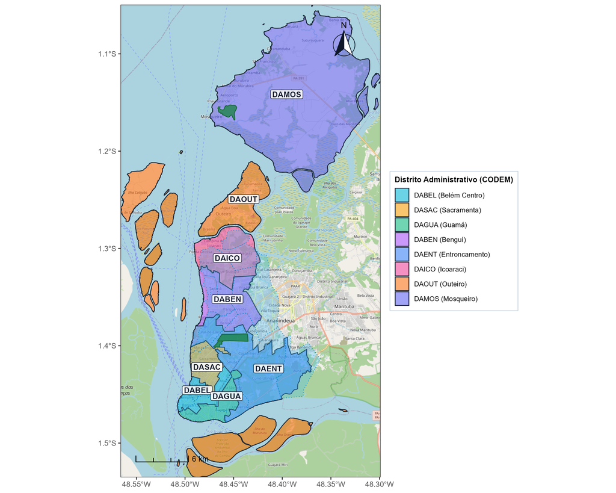

Fonte: Elaborado pelo CISC Belém, através dos dados da CODEM, da SEGEP e do IBGE. Mapa de fundo: © OpenStreetMap contributors.

O mapa delimita os 8 Distritos Administrativos da CODEM (Lei Municipal nº 7.682/1994), nas porções continental e insular de Belém, e sobrepõe 14 bacias hidrográficas urbanas e 3 áreas de preservação e parques (Parque Ambiental de Belém; Parque Ecológico de Belém; Parque Municipal do Mosqueiro).

**Clima:** Belém tem clima equatorial quente e úmido (Af, na classificação de Köppen), com temperatura média próxima de 26,5 °C e precipitação anual acima de 2.800 mm; a caracterização calculada com a série local está na seção 3.2.

**Eventos extremos e períodos do ano:** Os maiores totais médios mensais de chuva ocorrem em março, abril e fevereiro, e os menores em setembro, agosto e outubro. Inundações e alagamentos dependem de registros próprios de ocorrência, e não da média de chuva.

### 3.1.1 Caracterização da população

**Densidade demográfica:** O Censo 2022 registra **1.303.403 residentes** e **1.230,25 habitantes por km²**. O mapa por Distrito Administrativo, com a malha da CODEM, permite comparar o adensamento entre as porções continental e insular (IBGE, 2022).

**Ocupação urbana e rural:** Belém é o núcleo de sua região metropolitana, com área urbanizada contínua de cerca de 147,35 km². Comércio, serviços e população concentram-se na porção continental, e as ilhas abrigam comunidades ribeirinhas de características rurais.

**Renda e escolaridade:** O rendimento domiciliar nominal médio mensal per capita é de R$ 1.668,52, o PIB per capita, de R$ 31.100,18, e a taxa de escolarização de 6 a 14 anos, de 98,08% (IBGE, Cidades e Estados).

#### Figura 2: Densidade demográfica por Distrito Administrativo (Censo 2022)

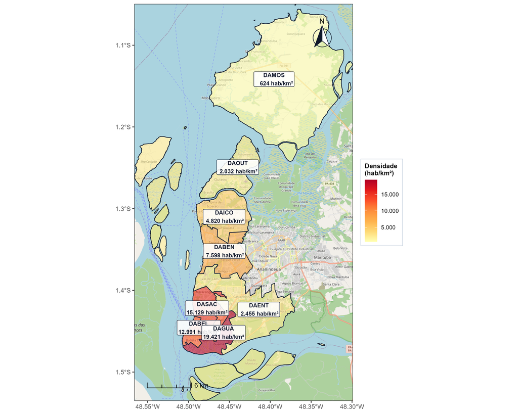

Fonte: Elaborado pelo CISC Belém, através dos dados do IBGE (Censo Demográfico 2022) e da CODEM. Mapa de fundo: © OpenStreetMap contributors.

A maior densidade foi a do DAGUA (19.421 hab/km²) e a menor, a do DAMOS (624 hab/km²).

Nota: a área de cada distrito é a soma das áreas dos bairros na base censitária (252,3 km² no total), inferior à área territorial do município (1.059,458 km²; IBGE). Nos distritos insulares (DAMOS e DAOUT) a área está subestimada e a densidade, superestimada. A população somada dos distritos (1.287.370) difere da população municipal do Censo 2022 (1.303.403).

Quadro 1: Distribuição demográfica por Distrito Administrativo

| Sigla | Distrito Administrativo | População | Área (km²) |
| --- | --- | --- | --- |
| DAGUA | Guamá | 147.263 | 7,6 |
| DASAC | Sacramenta | 206.330 | 13,6 |
| DABEL | Belém | 276.865 | 21,3 |
| DABEN | Benguí | 244.532 | 32,2 |
| DAICO | Icoaraci | 173.723 | 36,0 |
| DAENT | Entroncamento | 176.827 | 72,0 |
| DAOUT | Outeiro | 26.602 | 13,1 |
| DAMOS | Mosqueiro | 35.228 | 56,4 |

Fonte: Elaborado pelo CISC Belém, através dos dados do IBGE (Censo Demográfico 2022) e da CODEM.

## 3.2 Seção 2: Cenários associados aos eventos climáticos e meteorológicos

### 3.2.1 Indicador de calor: temperatura (máxima, média ou mediana), índice de calor, sensação térmica e Fator de Excesso de Calor (EHF)

#### Figura 3: Completude das séries meteorológicas

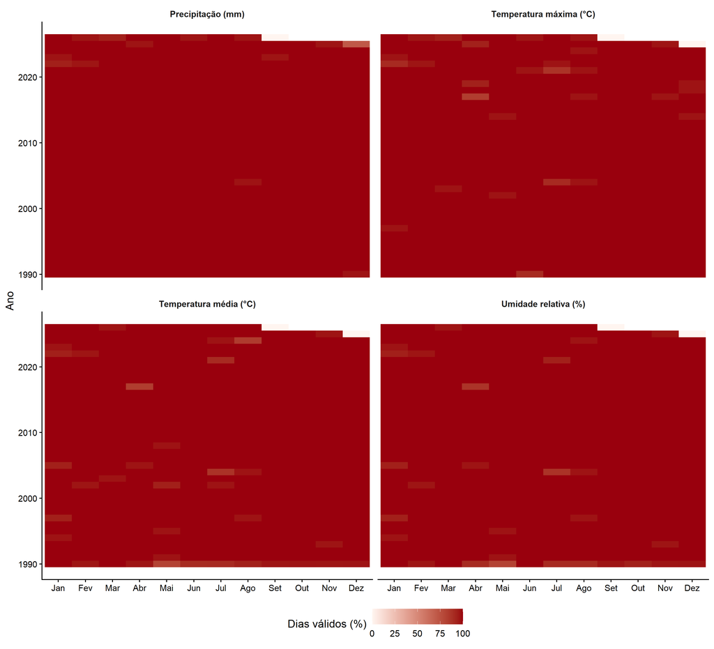

Fonte: Elaborado pelo CISC Belém, através dos dados do INMET. Período: 01/1990 a 12/2025.

Os meses aprovados pelos critérios de cobertura foram: temperatura média, 431/432; média das máximas diárias, 431/432; precipitação, 423/432; umidade relativa, 431/432. A proporção de dias válidos varia por mês; ausência de observação não equivale a valor climático zero.

#### Figura 4: Decomposição temporal e autocorrelação dos resíduos

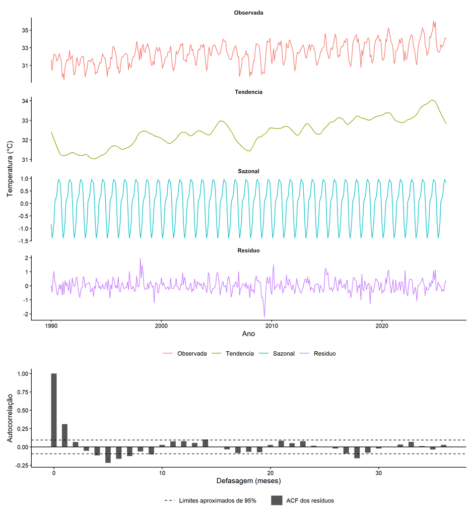

Fonte: Elaborado pelo CISC Belém, através dos dados do INMET. Período: 01/01/1990 a 01/11/2025.

No bloco de 01/1990 a 11/2025, a componente de tendência da temperatura variou +0,39 °C. A amplitude sazonal foi de 2,35 °C. A ACF residual ultrapassou os limites aproximados em 8 de 36 defasagens avaliadas.

#### Figura 5: Referência climatológica mensal da temperatura média e máxima

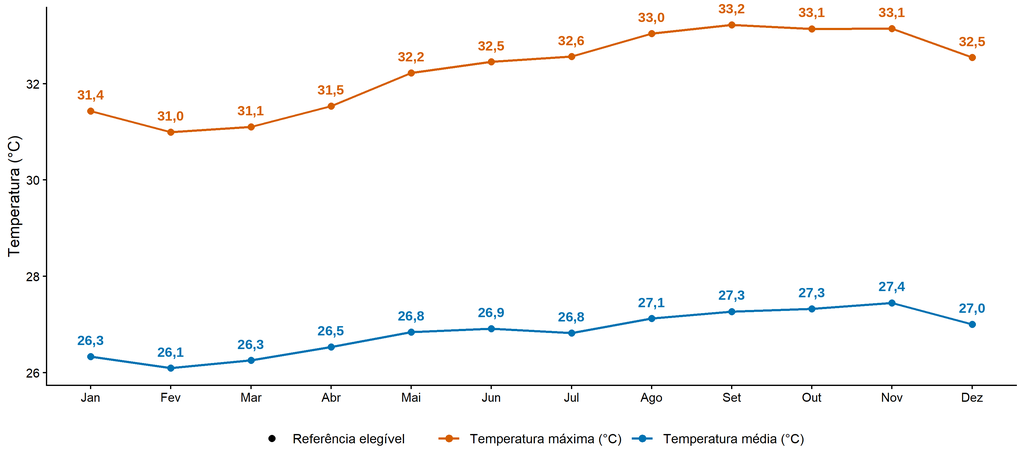

Fonte: Elaborado pelo CISC Belém, através dos dados do INMET. Período: 1991–2020; meses elegíveis segundo a cobertura.

As médias mensais de 1991–2020 apresentaram os seguintes extremos: temperatura média: 26,1 °C em Fev e 27,4 °C em Nov; média das máximas diárias: 31,0 °C em Fev e 33,2 °C em Set.

#### Figura 6: Painel de séries temporais históricas de temperatura, precipitação e umidade de 1990 a 2025

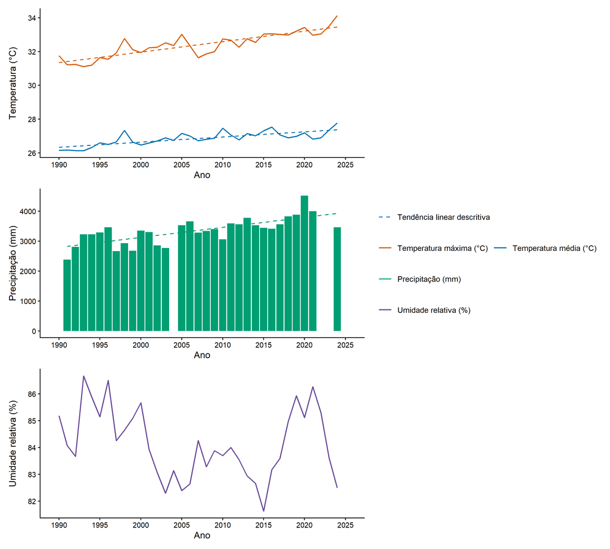

Fonte: Elaborado pelo CISC Belém, através dos dados do INMET. Período: 1990–2025.

Nas séries anuais, as tendências descritivas foram: temperatura média +0,30 °C/década (1990–2024); média das máximas diárias +0,62 °C/década (1990–2024); precipitação +334,12 mm/década (1991–2024). Os demais valores variaram: umidade relativa de 81,6% (2015) a 86,7% (1993).

#### Figura 7: Anomalias mensais de temperatura em escala absoluta (°C)

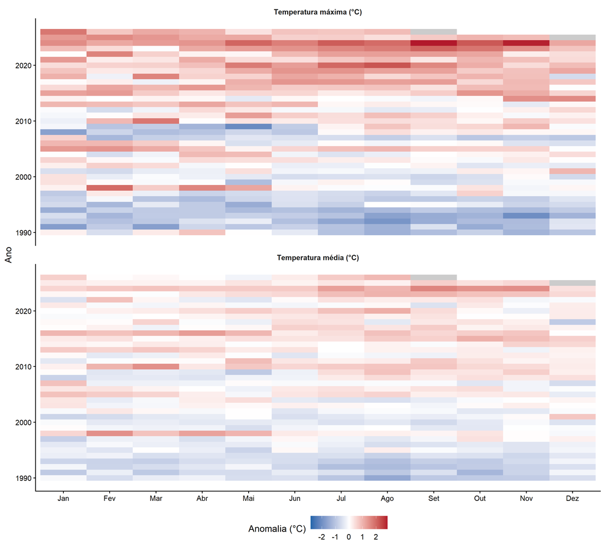

Fonte: Elaborado pelo CISC Belém, através dos dados do INMET. Período: 01/1990 a 12/2025; referência 1991–2020.

Temperatura média: 52,4% dos meses acima da referência; maior anomalia +1,6 °C em 09/2024; média das máximas diárias: 56,8% dos meses acima da referência; maior anomalia +2,8 °C em 09/2024. As comparações usam a referência mensal de 1991–2020.

#### Figura 8: Evolução das anomalias mensais de temperatura

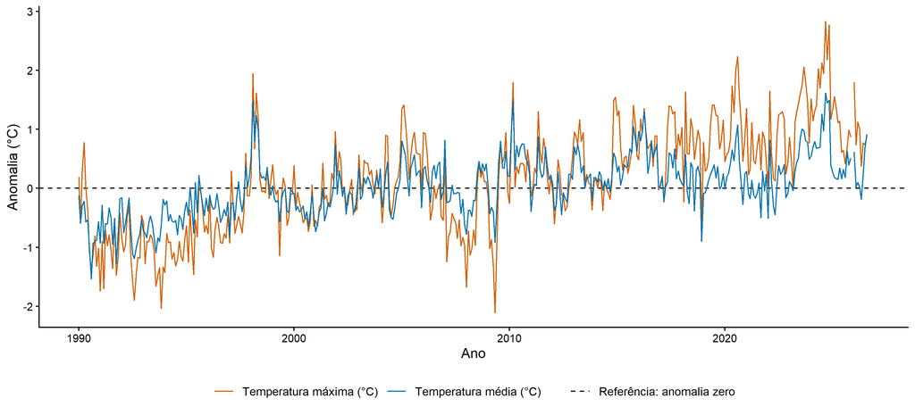

Fonte: Elaborado pelo CISC Belém, através dos dados do INMET. Período: 01/1990 a 12/2025; referência 1991–2020.

Temperatura média: +0,5 °C em 11/2025 (último mês válido); média das máximas diárias: +0,9 °C em 11/2025 (último mês válido). As comparações usam a referência mensal de 1991–2020.

#### Figura 9: Indicador de calor, série mensal da temperatura adotada

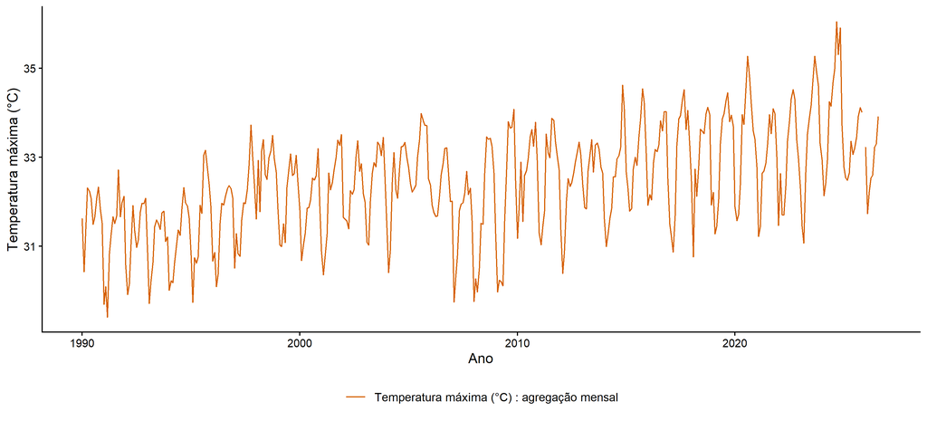

Fonte: Elaborado pelo CISC Belém, através dos dados do INMET. Período: 01/1990 a 12/2025.

A média das máximas diárias foi de 34,0 °C em 11/2025, último mês válido. A série reúne 431 meses avaliáveis entre 01/1990 e 11/2025.

#### Figura 10: Distribuição mensal do indicador de calor

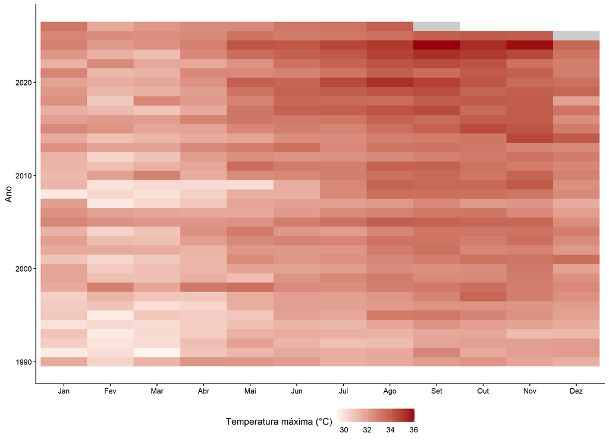

Fonte: Elaborado pelo CISC Belém, através dos dados do INMET. Período: 01/1990 a 12/2025.

Nos meses avaliáveis, a média das máximas diárias atingiu 36,0 °C em 09/2024, maior valor da série mensal. O menor foi 29,4 °C em 03/1991.

#### Figura 11: Temperatura mínima noturna, limiares P90 e P95 sazonais e episódios de noites quentes consecutivas

[figure not shown]

Fonte: Elaborado pelo CISC Belém, através dos dados do INMET. Período: 01/01/2015 a 31/08/2026.

Houve 63 episódios de três ou mais noites consecutivas acima do P90 (até 7 noites) e 27 acima do P95 (até 5); 2023 e 2024 concentraram 67% dos episódios P90. Essas sequências indicam ausência de recuperação térmica noturna, com maior risco para idosos, crianças e pessoas com doenças crônicas.

Nota: mínima noturna entre 18 h e 6 h (estação A201), com dados em 91% a 100% das noites por ano (2026 até 31/08); lacunas na linha são noites sem dado. Um valor implausível (−5,0 °C em 11/03/2020) foi omitido.

#### Índice de calor horário e máximo diário

#### Figura 12: Índice de calor máximo diário em Belém (estação A201)

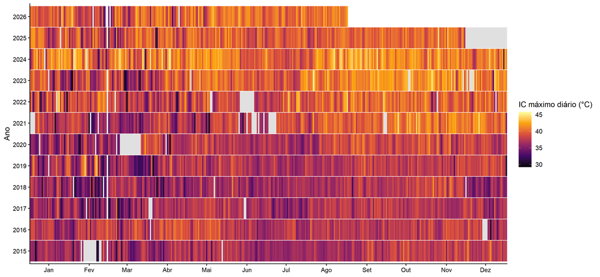

Fonte: Elaborado pelo CISC Belém, através dos dados do INMET: estação automática A201. Período: 01/01/2015 a 31/08/2026.

A A201 apresentou IC máximo calculável em 4123 de 4261 dias do calendário analisado. O maior valor foi 45,8 °C em 17/04/2024, com temperatura de 32,9 °C e umidade de 76,0% na mesma hora. Cinza representa IC ausente, não valor zero.

#### Figura 13: Distribuição média do IC máximo diário por mês e dia

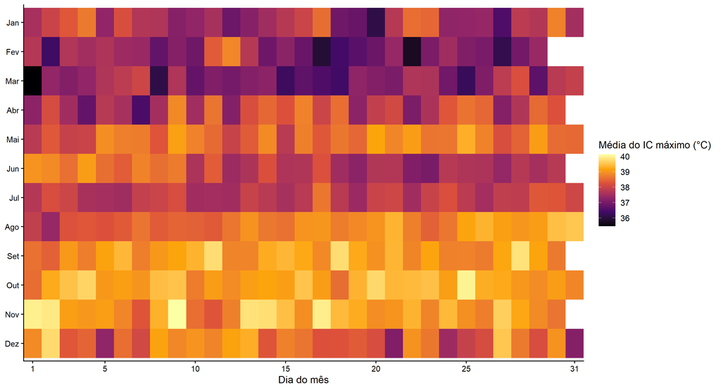

Fonte: Elaborado pelo CISC Belém, através dos dados do INMET: estação automática A201. Período: 01/01/2015 a 31/08/2026.

No calendário amostral, a maior média do IC máximo foi 40,1 °C em 9 de novembro, com 11 anos válidos nessa célula. As células não possuem necessariamente a mesma cobertura; não se trata de uma normal de 30 anos.

### 3.2.2 Definição das métricas de calor e regressão quantílica

#### Figura 14: Regressão quantílica sazonal (Q5, Q25, Q50, Q75 e Q95)

[figure not shown]

Fonte: Elaborado pelo CISC Belém, através dos dados do INMET. Período: 01/01/2026 a 30/09/2026.

Em 2026, nos 238 dias avaliáveis, a temperatura superou Q5 em 222 dias (93,3%); Q25 em 142 dias (59,7%); Q50 em 80 dias (33,6%); Q75 em 15 dias (6,3%); Q95 em 1 dia (0,4%). As contagens se sobrepõem entre quantis. Como os quantis incluem a tendência de 1990 a 2025 projetada para 2026, frequências abaixo do nominal indicam um ano abaixo da tendência; isso não contradiz a excedência do P90 fixo da normal 1991 a 2020 (figura seguinte), que mede o afastamento em relação à normal.

#### Figura 15: Episódios de calor e P90 sazonal fixo

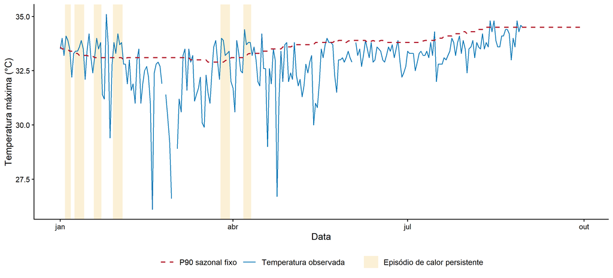

Fonte: Elaborado pelo CISC Belém, através dos dados do INMET. Período: exibição 2026 até 30/09/2026; referência 1991–2020.

Em 2026, 52 de 238 dias avaliáveis (21,8%) superaram o P90 sazonal. Pela definição do P90, esperam-se 10% dos dias. Foram identificados 6 episódios persistentes; o mais longo durou 5 dias, de 09/01/2026 a 13/01/2026, consideradas suas datas completas.

## 3.3 Seção 3: Cenários climáticos e suas implicações para a saúde

Os resultados de saúde referem-se a residentes em Belém, de 2015 a 2026, conforme a cobertura de cada fonte. Em cada série, o IP95% é ultrapassado por acaso em cerca de 2,5% das semanas (cerca de 15 em 600); números próximos disso não indicam excesso. Os saldos observado menos esperado são descritivos e não estimam a parcela de óbitos ou internações atribuível ao clima.

### 3.3.1 Mortalidade observada e esperada

#### Figura 16: Mortalidade geral observada e esperada com episódios de calor

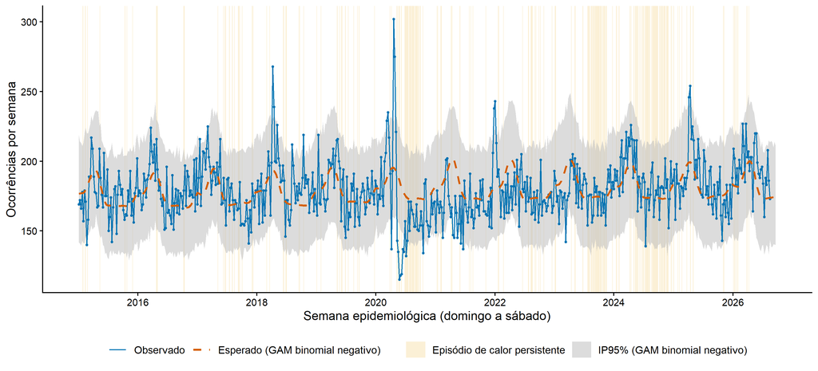

Fonte: Elaborado pelo CISC Belém, através dos dados do SIM; do INMET. Período: 04/01/2015 a 22/08/2026.

De 04/01/2015 a 22/08/2026, em relação à mortalidade geral (SIM), foram observados 109.014 óbitos frente a 108.842,2 esperados em 607 semanas. O saldo foi de +171,8 óbitos, com 15 semanas acima do IP95%. A comparação abrange todas as semanas válidas, não apenas as dos episódios climáticos.

**Nota:** exclusões de COVID-19 e de códigos substitutos conforme a seção 2.2; série até a semana epidemiológica 33 de 2026.

### 3.3.2 Mortalidade por causas específicas sensíveis ao calor

#### Figura 17: Mortalidade por doenças cardiovasculares e episódios de calor

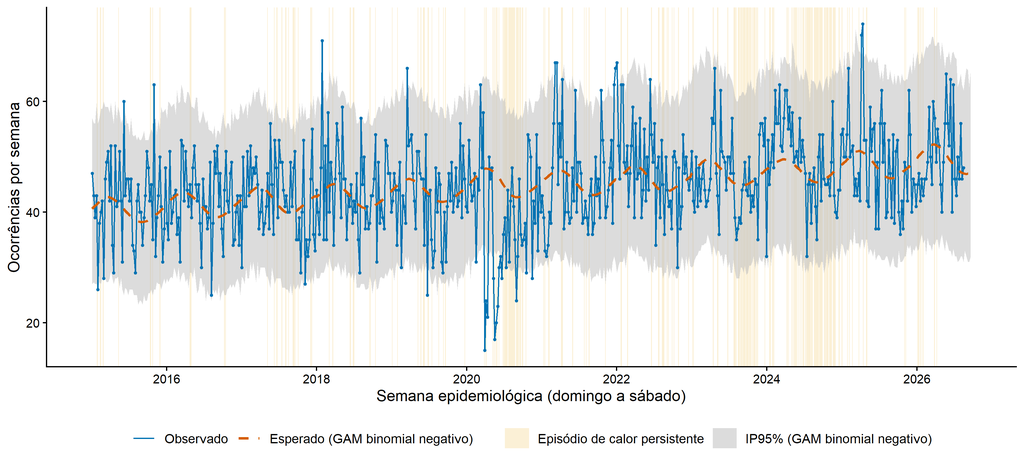

Fonte: Elaborado pelo CISC Belém, através dos dados do SIM; do INMET. Período: 04/01/2015 a 22/08/2026.

De 04/01/2015 a 22/08/2026, em relação à mortalidade por doenças cardiovasculares (SIM), foram observados 27.274 óbitos frente a 27.231,0 esperados em 607 semanas. O saldo foi de +43,0 óbitos, com 15 semanas acima do IP95%. A comparação abrange todas as semanas válidas, não apenas as dos episódios climáticos.

**Nota:** exclusões de COVID-19 e de códigos substitutos conforme a seção 2.2; série até a semana epidemiológica 33 de 2026.

#### Figura 18: Mortalidade por doenças respiratórias e episódios de calor

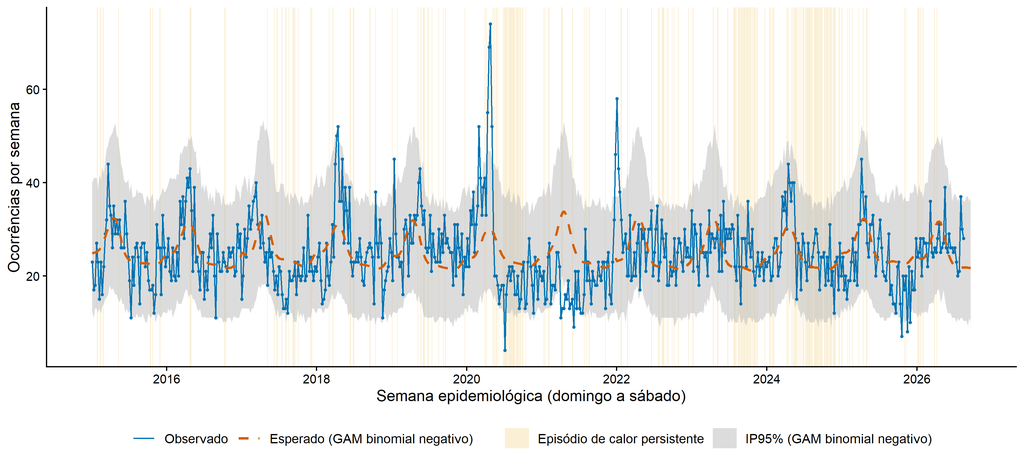

Fonte: Elaborado pelo CISC Belém, através dos dados do SIM; do INMET. Período: 04/01/2015 a 22/08/2026.

De 04/01/2015 a 22/08/2026, em relação à mortalidade por doenças respiratórias (SIM), foram observados 15.116 óbitos frente a 15.131,3 esperados em 607 semanas. O saldo foi de -15,3 óbitos, com 15 semanas acima do IP95%. A comparação abrange todas as semanas válidas, não apenas as dos episódios climáticos.

**Nota:** exclusões de COVID-19 e de códigos substitutos conforme a seção 2.2; série até a semana epidemiológica 33 de 2026.

#### Figura 19: Mortalidade por doenças renais e episódios de calor

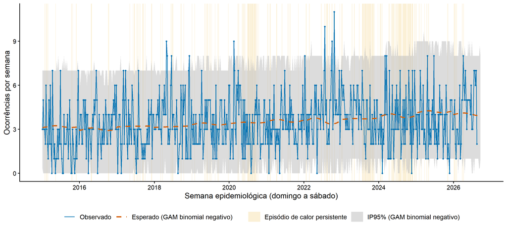

Fonte: Elaborado pelo CISC Belém, através dos dados do SIM; do INMET. Período: 04/01/2015 a 22/08/2026.

De 04/01/2015 a 22/08/2026, em relação à mortalidade por doenças renais (SIM), foram observados 2.125 óbitos frente a 2.136,1 esperados em 607 semanas. O saldo foi de -11,1 óbitos, com 7 semanas acima do IP95%. A comparação abrange todas as semanas válidas, não apenas as dos episódios climáticos.

**Nota:** exclusões de COVID-19 e de códigos substitutos conforme a seção 2.2; série até a semana epidemiológica 33 de 2026.

#### Figura 20: Mortalidade por diabetes e episódios de calor

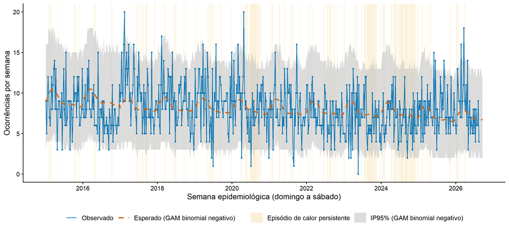

Fonte: Elaborado pelo CISC Belém, através dos dados do SIM; do INMET. Período: 04/01/2015 a 22/08/2026.

De 04/01/2015 a 22/08/2026, em relação à mortalidade por diabetes (SIM), foram observados 4.917 óbitos frente a 4.925,1 esperados em 607 semanas. O saldo foi de -8,1 óbitos, com 15 semanas acima do IP95%. A comparação abrange todas as semanas válidas, não apenas as dos episódios climáticos.

**Nota:** exclusões de COVID-19 e de códigos substitutos conforme a seção 2.2; série até a semana epidemiológica 33 de 2026.